# Introductory Statistics with Randomization and Simulation: Chapter 5

## Line Fitting, Residuals and Correlation

## Modeling Numerical Variables

In this unit we will learn to quantify the relationship between two numerical variables, as well as modeling numerical response variables using a numerical or categorical explanatory variable.

## Poverty versus High School graduation rate

**Response Variable**?

## Poverty versus High School graduation rate

**Response Variable**? Percentage in poverty

## Poverty versus High School graduation rate

**Response Variable**? Percentage in poverty

**Explanatory Variable**?

## Poverty versus High School graduation rate

**Response Variable**? Percentage in poverty

**Explanatory Variable**? Percentage of HS graduates

## Poverty versus High School graduation rate

**Response Variable**? Percentage in poverty

**Explanatory Variable**? Percentage of HS graduates

**Relationship**?

## Poverty versus High School graduation rate

**Response Variable**? Percentage in poverty

**Explanatory Variable**? Percentage of HS graduates

**Relationship**? Linear, negative, moderately strong

## Quantifying the Relationship

- **Correlation** describes the *strength* of the *linear* association between the two variables

## Quantifying the Relationship

- **Correlation** describes the *strength* of the *linear* association between the two variables
- Takes on values between \(-1\) and \(+1\) (inclusive)

## Quantifying the Relationship

- **Correlation** describes the *strength* of the *linear* association between the two variables
- Takes on values between \(-1\) and \(+1\) (inclusive)
- A value of \(0\) indicates no linear association

## Guessing the Correlation

Which of the following is the best guess for the correlation between percentage in poverty and percentage of HS graduates?

- 0.6
- -0.75
- -0.1
- 0.02
- -1.5

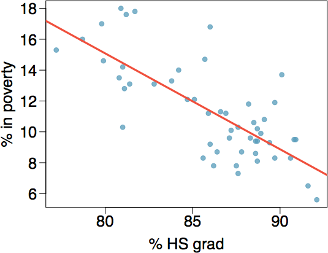

## Guessing the Correlation

Which of the following is the best guess for the correlation between percentage in poverty and percentage of HS graduates?

- 0.6
- **-0.75**
- -0.1
- 0.02
- -1.5

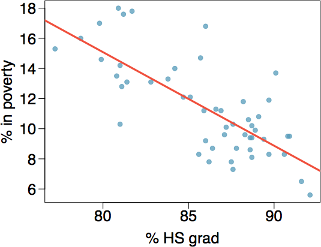

## Guessing the Correlation (2)

Which of the following is the best guess for the correlation between percentage in povery and percentage of female householder.

- 0.1
- -0.6
- -0.4
- 0.9
- 0.5

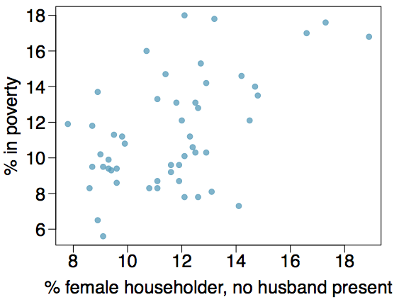

## Guessing the Correlation (2)

Which of the following is the best guess for the correlation between percentage in povery and percentage of female householder.

- 0.1
- -0.6
- -0.4
- 0.9
- **0.5**

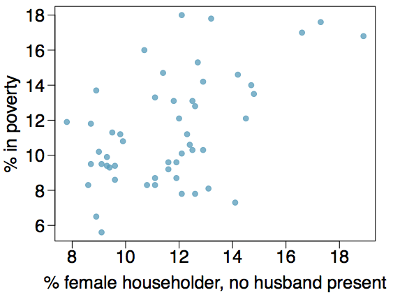

## Assessing the Correlation

Which of the following has the strongest correlation, i.e., the correlation coefficient closest to \(-1\) or \(+1\).

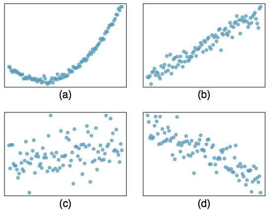

## Assessing the Correlation

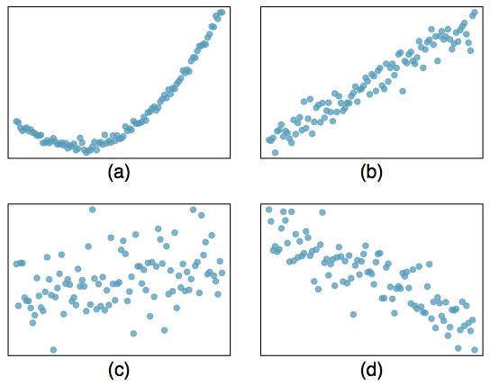

**Option (b)**. While (a) clearly 'tracks', it's not actually *linear*.

## Fitting a line by least squares regression

## Eyeballing the line

Which of the following appears to be the line that best fits the linear relationship between percentage in poverty and percentage of HS grad? Choose one.

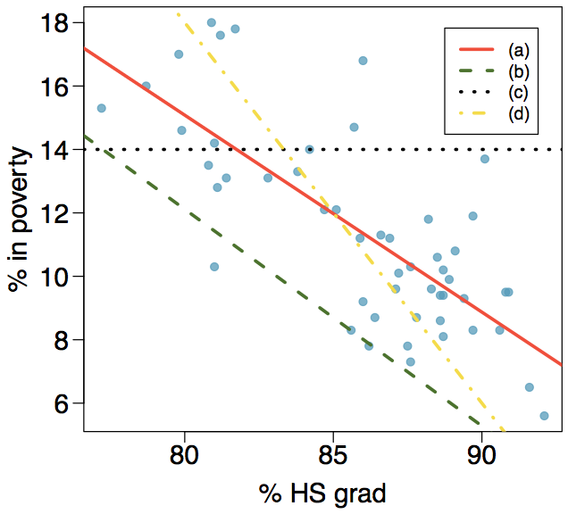

## Eyeballing the linear

Which of the following appears to be the line that best fits the linear relationship between percentage in poverty and percentage of HS grad? Choose one.

The best fit appears to be **(a)** (over (d)). (b) and (c) aren't good fits at all.

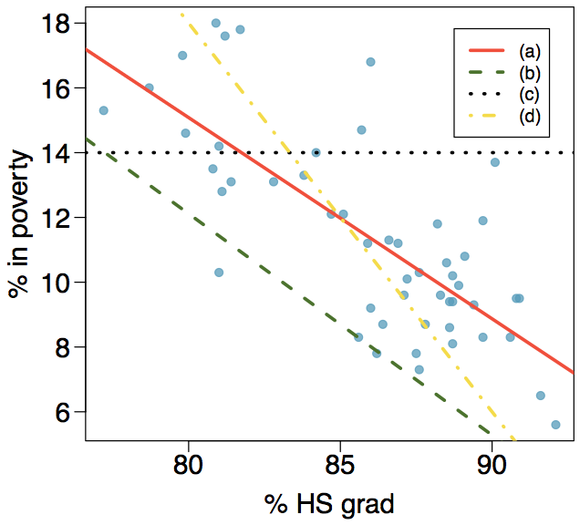

## Residuals

**Residuals** are the leftovers from the model fit.

\[ \text{Data} = \text{Fit} + \text{Residuals} \]

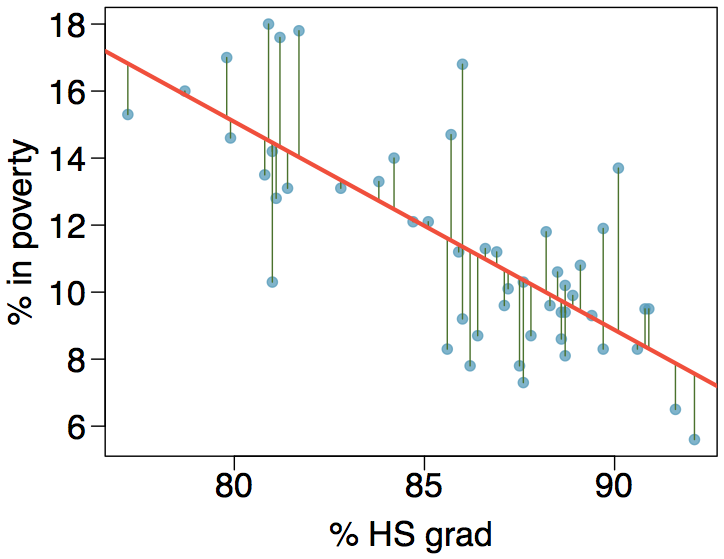

## Residuals (ctd.)

**Residuals** are the difference between the observed (\(y_i\)) and the predicted (\(\hat{y}_i\)). We label these as \(e_i\).

\[ e_i = y_i - \hat{y}_i \]

**Note**: the other way is **not** correct! We always take observed *minus* predicted, not the other way around.

## Residuals (ctd.)

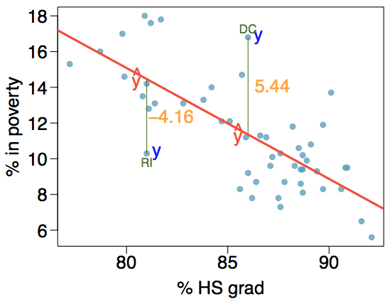

The labeled points indicate that:

- % living in poverty in DC is 5.44% more than predicted.
- % living in poverty in RI is 4.16% less than predicted.

## A measure for the best line

- We want a line that has small residuals

## A measure for the best line

- We want a line that has small residuals
  - **Option 1**: minimize the sum of the absolute values of the residuals, \[ |e_1| + |e_2| + \cdots + |e_n| \]

## A measure for the best line

- We want a line that has small residuals
  - **Option 1**: minimize the sum of the absolute values of the residuals, \[ |e_1| + |e_2| + \cdots + |e_n| \]
  - **Option 2**: minimize the sum of the *squared* residuals (*least squares*) \[ e_1^2 + e_2^2 + \cdots + e_n^2 \]

## A measure for the best line

- We want a line that has small residuals
  - **Option 1**: minimize the sum of the absolute values of the residuals, \[ |e_1| + |e_2| + \cdots + |e_n| \]
  - **Option 2**: minimize the sum of the *squared* residuals (*least squares*) \[ e_1^2 + e_2^2 + \cdots + e_n^2 \]
- Why least squares?

## A measure for the best line

- We want a line that has small residuals
  - **Option 1**: minimize the sum of the absolute values of the residuals, \[ |e_1| + |e_2| + \cdots + |e_n| \]
  - **Option 2**: minimize the sum of the *squared* residuals (*least squares*) \[ e_1^2 + e_2^2 + \cdots + e_n^2 \]
- Why least squares?
  - Most commonly used

## A measure for the best line

- We want a line that has small residuals
  - **Option 1**: minimize the sum of the absolute values of the residuals, \[ |e_1| + |e_2| + \cdots + |e_n| \]
  - **Option 2**: minimize the sum of the *squared* residuals (*least squares*) \[ e_1^2 + e_2^2 + \cdots + e_n^2 \]
- Why least squares?
  - Most commonly used
  - Easier to compute by hand, and with software

## A measure for the best line

- We want a line that has small residuals
  - **Option 1**: minimize the sum of the absolute values of the residuals, \[ |e_1| + |e_2| + \cdots + |e_n| \]
  - **Option 2**: minimize the sum of the *squared* residuals (*least squares*) \[ e_1^2 + e_2^2 + \cdots + e_n^2 \]
- Why least squares?
  - Most commonly used
  - Easier to compute by hand, and with software
  - In many applications, a residual twice as large is more than twice **as bad**

## The least squares line

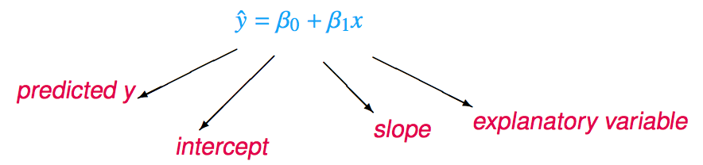

**Notation**:

- Intercept
  - Parameter: \(\beta_0\)
  - Point estimate: \(b_0\)
- Slope
  - Parameter: \(\beta_1\)
  - Point estimate: \(b_1\)

## Given \(\ldots\)

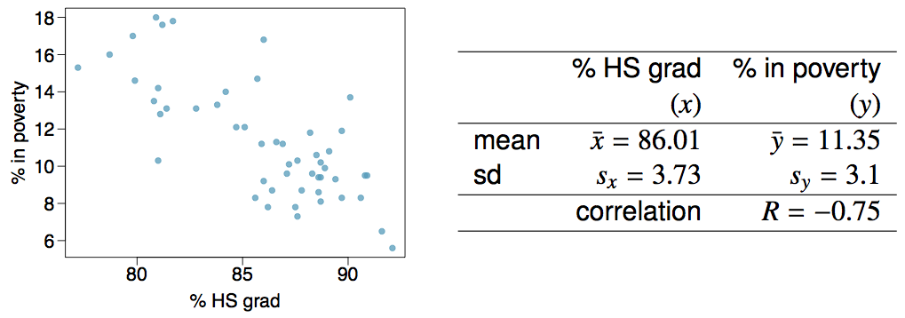

## Slope

The slope of the regression line (remember: \(y = mx + b\)) can be calculated as

\[ b_1 = \frac{s_y}{s_x} R \]

In context:

\[ b_1 = \frac{3.1}{3.73} \cdot -0.75 = -0.62 \]

**Interpretation**: for each additional percentage point in HS graduation rate, we would expect the percentage living in poverty to be lower on average by 0.62% points.

## Intercept

The intercept is where the regression line intersects the y-axis. The calculation of the intercept uses the fact the a regression line always passes through (\(\bar{x}, \bar{y}\)).

\[ b_0 = \bar{y} - b_1 \bar{x} \]

## Intercept

\[ b_0 = \bar{y} - b_1 \bar{x} \]

We calculate: \[ b_0 = 11.35 - (-0.62) \cdot 86.01 = 64.68 \]

## Practice

Which of the following is the correct interpretation of the intercept?

- For each % point increase in HS graduation rates, the % living in poverty is expected to increase on average by 64.68%.
- For each % point decrease in HS graduation rate, the % living in poverty is expected to increase on average by 64.68%.
- Having no HS graduates leads to 64.68% of residents living below the poverty line.
- States with no HS graduates are expected on average to have 64.68% of residents living below the poverty line.
- In states with no HS graduates the % living in poverty is expected to increase on average by 64.68%.

## Practice

Which of the following is the correct interpretation of the intercept?

- For each % point increase in HS graduation rates, the % living in poverty is expected to increase on average by 64.68%.
- For each % point decrease in HS graduation rate, the % living in poverty is expected to increase on average by 64.68%.
- Having no HS graduates leads to 64.68% of residents living below the poverty line.
- **States with no HS graduates are expected on average to have 64.68% of residents living below the poverty line.**
- In states with no HS graduates the % living in poverty is expected to increase on average by 64.68%.

## More on the intercept

Since there are no states in the data set with zero HS graduates, the intercept is of no interest, not very useful, and also **not reliable** since the predicted value of the intecept is so far from **all** of the data.

## Regression Line

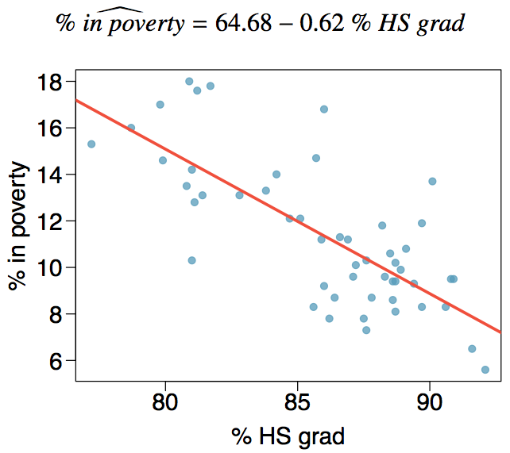

## Interpretation of slope and intercept

- **Intercept**: when \(x=0\), \(y\) is expected to equal the intercept
- **Slope**: for each unit change in \(x\), \(y\) is expected to increase/decrease on average by the value of the slope.

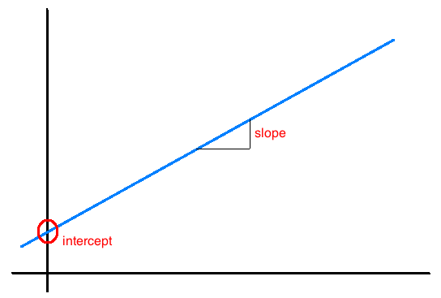

**Note**: these statements are **not** causal, unless the study is a randomized controlled experiment.

## Prediction

- Using the linear model to predict the value of the response variable for a given value of the explanatory variable is called **prediction**, and consists of plugging the value of \(x\) into the linear model equation
- There will be some uncertainty associated with the predicted value

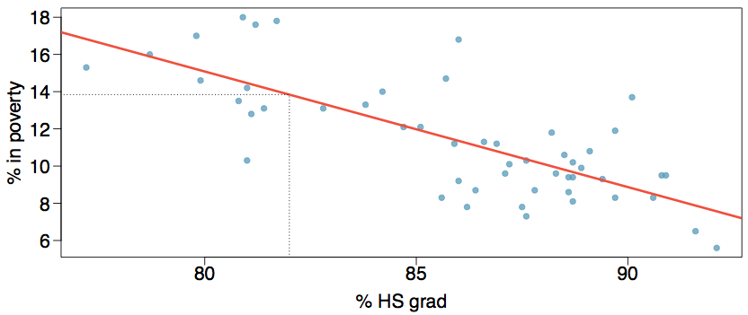

## Extrapolation

- Applying a model estimate to values outside of the range of the original data is called **extrapolation**
- Sometimes the intercept is an extrapolation

## Examples of Extrapolation

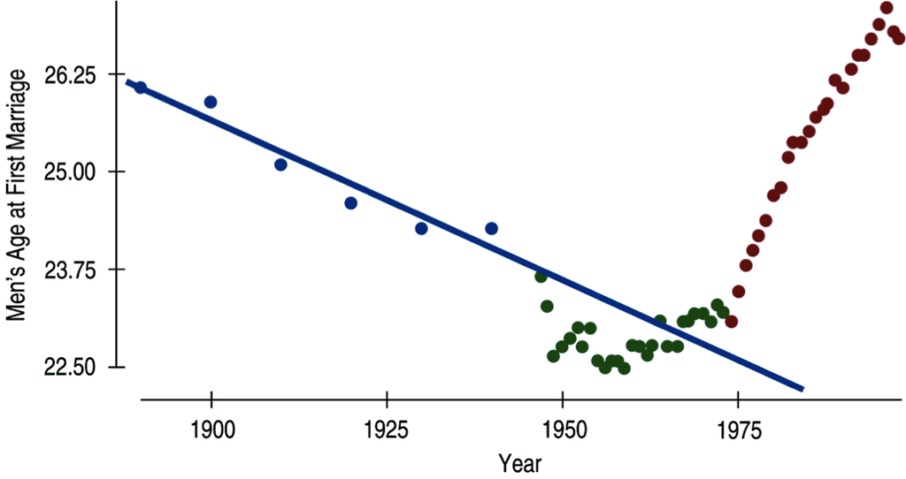

## Examples of Extrapolation

[figure not shown]

## Examples of Extrapolation

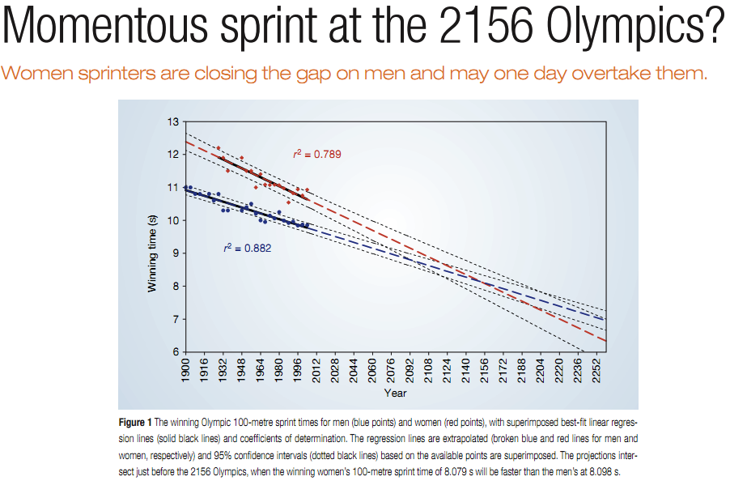

## Conditions for Least Squares Lines

- Linearity

## Conditions for Least Squares Lines

- Linearity
- Nearly normal residuals

## Conditions for Least Squares Lines

- Linearity
- Nearly normal residuals
- Constant variability

## Conditions: (1) Linearity

- the relationships between the explanatory and response variables should be linear

## Conditions: (1) Linearity

- the relationships between the explanatory and response variables should be linear
- methods for fitting a model to non-linear relationships exist, but are mostly beyond the scope of this course

## Conditions: (1) Linearity

- the relationships between the explanatory and response variables should be linear
- methods for fitting a model to non-linear relationships exist, but are mostly beyond the scope of this course
- check using a scatterplot or residual plot of the data (or both)

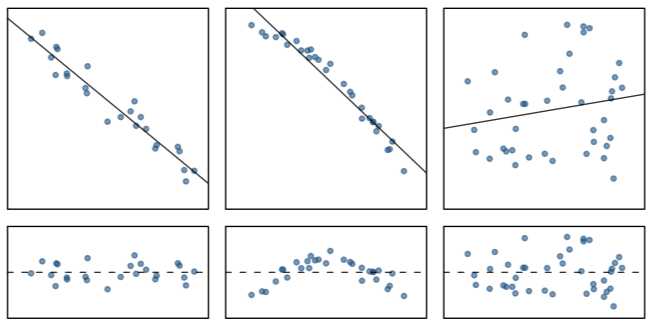

## Anatomy of a residuals plot

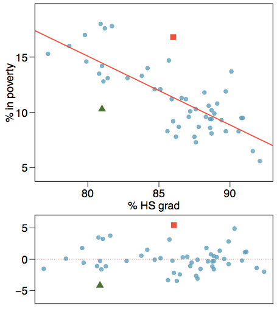

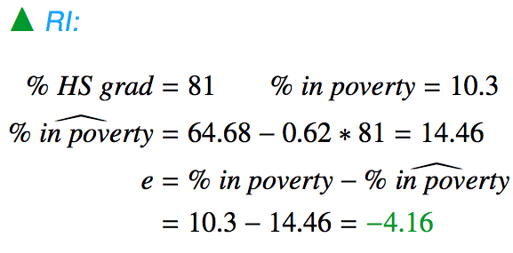

## Anatomy of a residuals plot

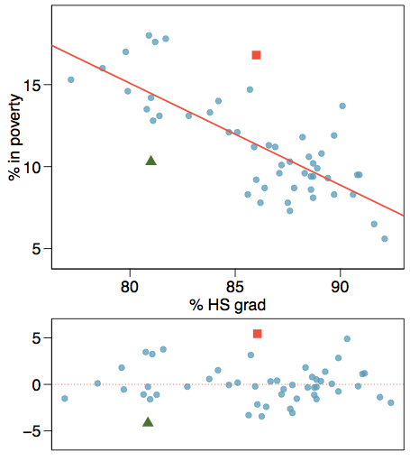

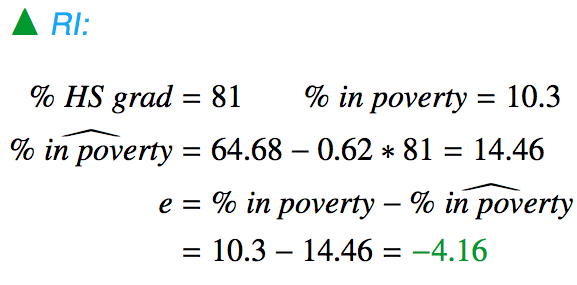

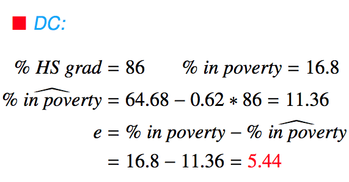

## Conditions: (2) Nearly normal residuals

- the residuals should be nearly normal

## Conditions: (2) Nearly normal residuals

- the residuals should be nearly normal
- this condition may not be satisfied when there are unusual observations that don't follow the trend of the rest of the data

## Conditions: (2) Nearly normal residuals

- the residuals should be nearly normal
- this condition may not be satisfied when there are unusual observations that don't follow the trend of the rest of the data
- check using a histogram and/or a normal QQ (probability) plot of the residuals

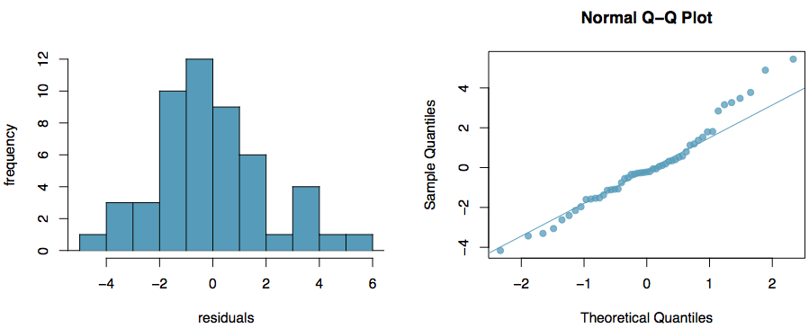

## Conditions: (3) Constant variability

- The variability of points around the least squares line should be roughly constant

## Conditions: (3) Constant variability

- The variability of points around the least squares line should be roughly constant
- This implies that the variability of the residuals around the \(0\) line should be roughly constant as well

## Conditions: (3) Constant variability

- The variability of points around the least squares line should be roughly constant
- This implies that the variability of the residuals around the \(0\) line should be roughly constant as well
- This is given the technical name **homoscedasticity**

## Example: Checking Conditions

What condition is this linear model obviously violating?

- Constant variability
- Linear relationship
- Normal residuals
- No extreme outliers

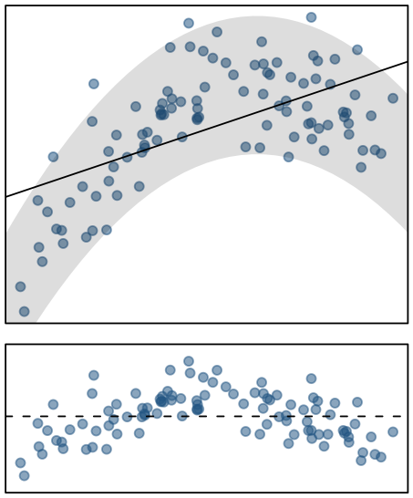

## Example: Checking Conditions

What condition is this linear model obviously violating?

- Constant variability
- **Linear relationship**
- Normal residuals
- No extreme outliers

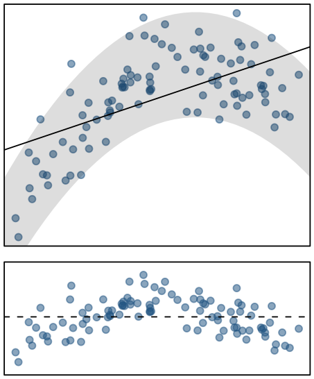

## Example: Checking Conditions

What condition is this linear model obviously violating?

- Constant variability
- Linear relationship
- Normal residuals
- No extreme outliers

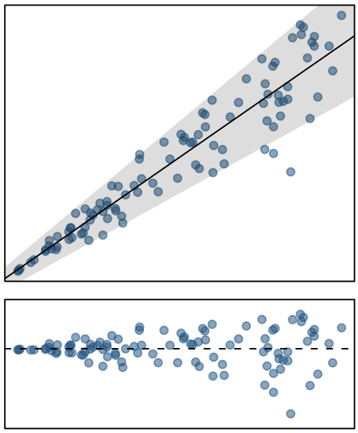

## Example: Checking Conditions

What condition is this linear model obviously violating?

- **Constant variability**
- Linear relationship
- Normal residuals
- No extreme outliers

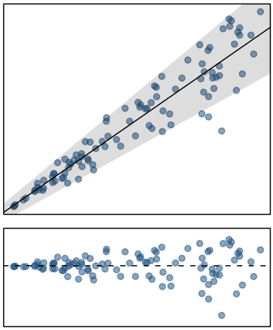

## \(R^2\)

- The strength of the fit of a linear model is most commonly evaluated using \(R^2\)

## \(R^2\)

- The strength of the fit of a linear model is most commonly evaluated using \(R^2\)
- \(R^2\) is calculated as the square of the correlation coefficient